# Array expression profiling

**Summary**

NOTCH proteins regulate signaling pathways involved in cellular differentiation, proliferation and death. Overactive Notch signaling as been observed in numerous cancers and has been extensively studied in the context of T-cell acute lymphoblastic leukemia (T-ALL) where more than 50% of pateints harbour mutant NOTCH1. Small molecule modulators of these proteins would be important for understanding the role of NOTCH proteins in malignant and normal biological processes.

We were interested to measure the global changes in gene expression upon treatment of the human T-ALL cell lines HPB-ALL and KOPT-K1 with either vehicle alone (DMSO) or SAHM1, an alpha-helical hydrocarbon stapled peptide derived from the MAML1 co-activator protein.

**Overall design** Triplicate cultures of KOPT-K1 or HPB-ALL cells were treated with either DMSO alone or SAHM1 (20 uM) for 24 hours. Total RNA was extracted and hybridized to Affymetrix human U133 plus 2.0 microarrays (three arrays per treatment per cell line for a total of 12 arrays).

## Python imports

```python
import rpy2.rinterface
%reload_ext rpy2.ipython
```

## R imports

```python
%%R
##1. Load libraries
library("affy")
library("limma")
library("genefilter")
library(simpleaffy)
library(hgu133plus2.db)
wd <- "/Users/nandoide/misc_work/Desktop/uni/TRREP"
setwd(wd)
```

## Functions

```python
%%R

import_CEL <- function(pattern) {
    # Import CEL files into affiBatch object
    files <- list.files(pattern = pattern)
    names <- gsub(".CEL.gz", "", files)
    abatch <- ReadAffy(filenames = files,  compress = TRUE, sampleNames = names)
    return(abatch)
}

create_eset <- function(affyBatch) {
    # Generates object eset (class ExprSet),
    # expresso function provides intensities in log scale
    return(expresso(affyBatch,
             bg.correct = TRUE,
             bgcorrect.method="rma",
             normalize = TRUE,
             normalize.method="quantiles",
             pmcorrect.method="pmonly",
             summary.method="medianpolish",
             verbose = TRUE))
}

boxplots <- function(affyBatch, eset, title) {
    # Generate BOXPLOTS before and after normalization
    boxplot(affyBatch,
        main=paste0("Boxplot Before Normalization ", title),
        col = "lightgrey")
    df_eset <- as.data.frame(exprs(eset))

    boxplot(data.frame(df_eset),
        main=paste0("Boxplot After Normalization (log scale) ", title), col = "white")
}

create_TopTable <- function(eset, control_samples=c(1,1,1,0,0,0)) {
    # Generate Toptable with limma

    # Data filtering using IQR.
    esetIQR <- varFilter(eset, var.func=IQR, var.cutoff=0.5, filterByQuantile=TRUE)

    # Differential expression analysis.#######
    r_control_samples <- 1 - control_samples
    design <- cbind(DMSO=control_samples, SAHM1=r_control_samples)

    rownames(design) <- colnames(eset)

    #7. Contrasts matrix.
    cont.matrix <- makeContrasts(DMSO_SAHM1 = SAHM1 - DMSO, levels = design)

    #8. Obtaining differentially expressed genes (DEGs)
    #Linear model and eBayes
    fit <- lmFit(esetIQR, design)  ##getting DEGs from IQR
    fit2 <- contrasts.fit(fit, cont.matrix)
    fit2 <- eBayes(fit2)

    #Table with DEGs results
    toptableIQR <- topTable(fit2, number=dim(exprs(esetIQR))[1], adjust.method="BH", sort.by="p")
    return(toptableIQR)
}

anotate_TopTable <- function(toptable) {
    # Obtain gene names from probe names and chip symbol dataset
    probenames_toptable <- as.character(rownames(toptable ))
    genesymbols_toptable <- as.character(mget(probenames_toptable, hgu133plus2SYMBOL))
    # Annotated gene table
    toptable_anot <- cbind(Symbol = genesymbols_toptable, toptable)
    return(toptable_anot)
}

generank_table <- function(toptable, rnk.file) {
    # Generate rank of table top 50 upregulared and top 50 downregulated from 250 better
    # adjustes p-values
    more_significant = toptable[order(toptable$adj.P.Val, decreasing = FALSE),][1:250,]
    up_50 = more_significant[which(toptable$logFC > 0), ] [1:50,] # up reg top 50
    down_50 = more_significant[which(toptable$logFC < 0), ] [1:50,] # down reg top 50

    print("Down-regulated genes")
    print(down_50[order(down_50$logFC), c(1,2,6)])

    print("Up-regulated genes")
    print(up_50[order(up_50$logFC), c(1,2,6)])

    d <- rbind(down_50[order(down_50$logFC), c(1,2,6)], up_50[order(up_50$logFC), c(1,2,6)])

    #df <- data.frame(paste0(d$Symbol, '|', row.names(d)), d$logFC)
    df <- data.frame(row.names(d), d$logFC)
    write.table(df,row.names=FALSE,col.names=FALSE,
                quote=FALSE,sep="\t",file=paste0(rnk.file, ".rnk"))
}
```

## Quality control

```
An object of class "QCStats"
Slot "scale.factors":
 [1] 0.4624769 0.9923886 0.5749658 0.5299016 0.4725059 0.4445994 1.4066966
 [8] 1.2441075 1.3089160 1.9466663 2.1150710 2.3084671

Slot "target":
[1] 100

Slot "percent.present":
  HPB_DMSO_01.present   HPB_DMSO_02.present   HPB_DMSO_03.present
             45.75583              41.61500              44.97485
 HPB_SAHM1_01.present  HPB_SAHM1_02.present  HPB_SAHM1_03.present
             45.39369              45.37906              46.93004
 KOPT_DMSO_01.present  KOPT_DMSO_02.present  KOPT_DMSO_03.present
             39.18793              39.72016              40.17558
KOPT_SAHM1_01.present KOPT_SAHM1_02.present KOPT_SAHM1_03.present
             38.46182              38.39049              38.57888

Slot "average.background":
  HPB_DMSO_01   HPB_DMSO_02   HPB_DMSO_03  HPB_SAHM1_01  HPB_SAHM1_02
     71.40948      51.82766      67.15371      73.25355      78.06755
 HPB_SAHM1_03  KOPT_DMSO_01  KOPT_DMSO_02  KOPT_DMSO_03 KOPT_SAHM1_01
     64.75102      58.67351      58.61665      56.23122      53.46125
KOPT_SAHM1_02 KOPT_SAHM1_03
     44.98804      45.99328

Slot "minimum.background":
  HPB_DMSO_01   HPB_DMSO_02   HPB_DMSO_03  HPB_SAHM1_01  HPB_SAHM1_02
     67.78476      49.90441      64.95388      68.98329      74.59893
 HPB_SAHM1_03  KOPT_DMSO_01  KOPT_DMSO_02  KOPT_DMSO_03 KOPT_SAHM1_01
     61.72838      56.40174      54.42714      53.83356      50.28008
KOPT_SAHM1_02 KOPT_SAHM1_03
     42.42914      43.87834

Slot "maximum.background":
  HPB_DMSO_01   HPB_DMSO_02   HPB_DMSO_03  HPB_SAHM1_01  HPB_SAHM1_02
     73.33486      52.82101      69.57489      75.70203      79.83810
 HPB_SAHM1_03  KOPT_DMSO_01  KOPT_DMSO_02  KOPT_DMSO_03 KOPT_SAHM1_01
     66.69588      60.24642      60.27544      57.78016      54.91569
KOPT_SAHM1_02 KOPT_SAHM1_03
```

[output cut: 68 more lines]

```
KOPT_SAHM1_02                  14.20615                  13.97154
KOPT_SAHM1_03                  14.29181                  14.05688

Slot "bioBCalls":
  HPB_DMSO_01.present   HPB_DMSO_02.present   HPB_DMSO_03.present
                  "P"                   "P"                   "P"
 HPB_SAHM1_01.present  HPB_SAHM1_02.present  HPB_SAHM1_03.present
                  "P"                   "P"                   "P"
 KOPT_DMSO_01.present  KOPT_DMSO_02.present  KOPT_DMSO_03.present
                  "P"                   "P"                   "P"
KOPT_SAHM1_01.present KOPT_SAHM1_02.present KOPT_SAHM1_03.present
                  "P"                   "P"                   "P"

Slot "arraytype":
[1] "hgu133plus2cdf"
```

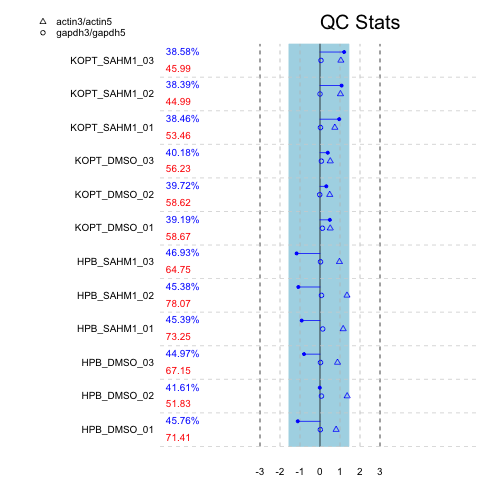

```python
%%R

setwd("GSE18198_data")
affyBatch = import_CEL("*")
setwd(wd)
affyBatch_MAS5 <- call.exprs(affyBatch,"mas5")
qcs <- qc(affyBatch, affyBatch_MAS5)
plot(qcs)
qcs
```

## Load raw data

```python
%%R
setwd("GSE18198_data")
affyBatch_HPB = import_CEL("HPB*")
affyBatch_KOPT = import_CEL("KOPT*")
setwd(wd)
```

## Create expression sets

```python
%%R
eset_HPB <- create_eset(affyBatch_HPB)
eset_KOPT <- create_eset(affyBatch_KOPT)
```

```
background correction: rma
normalization: quantiles
PM/MM correction : pmonly
expression values: medianpolish
background correcting...done.
normalizing...done.
54675 ids to be processed
|                    |
|####################|
background correction: rma
normalization: quantiles
PM/MM correction : pmonly
expression values: medianpolish
background correcting...done.
normalizing...done.
54675 ids to be processed
|                    |
|####################|
```

```python
%%R
save(eset_HPB, file="eset_HPB.RData")
save(eset_KOPT, file="eset_KOPT.RData")
```

## Quality plots

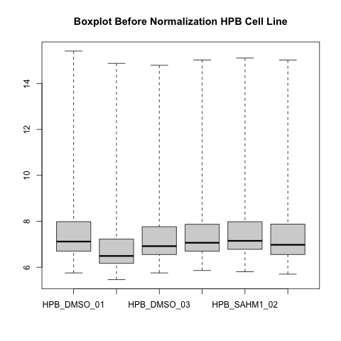

[figure not shown]

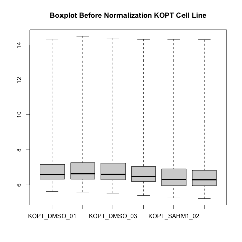

[figure not shown]

```python
%%R
boxplots(affyBatch_HPB, eset, "HPB Cell Line")
boxplots(affyBatch_KOPT, eset, "KOPT Cell Line")
```

## Differential expressed genes

```python
%%R
toptable_HPB <- create_TopTable(eset_HPB)
toptable_anot_HPB <- anotate_TopTable(toptable_HPB)
generank_table(toptable_anot_HPB, "generank_HPB")
```

```
[1] "Down-regulated genes"
               Symbol      logFC    adj.P.Val
225342_at         AK4 -2.1078858 1.128982e-05
230710_at    MIR210HG -1.9761492 7.688286e-06
227336_at        DTX1 -1.3841443 8.636324e-05
201842_s_at    EFEMP1 -1.3678548 6.004820e-05
204348_s_at       AK4 -1.3491612 3.350727e-04
227347_x_at      HES4 -1.2640712 1.228528e-04
200953_s_at     CCND2 -1.2357909 7.997079e-05
202464_s_at    PFKFB3 -1.1937490 1.228528e-04
202022_at       ALDOC -1.1753644 1.248092e-04
240546_at   LINC01120 -1.1131135 1.552628e-04
227337_at     ANKRD37 -1.1079168 2.110727e-04
200894_s_at     FKBP4 -1.0737202 5.300330e-04
217078_s_at    CD300A -1.0719092 8.239876e-04
201170_s_at   BHLHE40 -1.0402130 2.549012e-04
202934_at         HK2 -1.0377714 2.104071e-04
201848_s_at     BNIP3 -1.0052154 6.744018e-04
218051_s_at    NT5DC2 -1.0049990 2.851346e-03
203394_s_at      HES1 -0.9993973 7.294799e-04
219371_s_at      KLF2 -0.9800918 3.918155e-04
201251_at         PKM -0.9787897 4.328581e-03
201849_at       BNIP3 -0.9724936 6.167814e-04
213746_s_at      FLNA -0.9705676 1.430899e-03
201516_at         SRM -0.9428084 1.627743e-03
203523_at        LSP1 -0.9360851 2.263449e-03
225944_at         NLN -0.9317256 1.421369e-03
214183_s_at     TKTL1 -0.9290362 2.452591e-03
236180_at          NA -0.9287828 3.049302e-03
201194_at     SELENOW -0.9285463 6.167814e-04
231922_at      ZNF276 -0.9269927 4.098501e-03
209933_s_at    CD300A -0.9049911 8.239876e-04
214752_x_at      FLNA -0.9018607 1.636952e-03
226348_at       FUT11 -0.8976507 1.075839e-03
201212_at        LGMN -0.8972886 1.381530e-03
218305_at        IPO4 -0.8783786 1.923264e-03
205544_s_at       CR2 -0.8502424 1.206402e-03
202145_at        LY6E -0.8406636 2.534145e-03
200859_x_at      FLNA -0.8368746 2.851346e-03
202887_s_at     DDIT4 -0.8271607 1.813467e-03
```

[output cut: 49 more lines]

```
222853_at          FLRT3 1.3254635 1.138577e-04
219270_at          CHAC1 1.3362724 3.651273e-05
202672_s_at         ATF3 1.3481402 3.651273e-05
218280_x_at           NA 1.3495011 1.272470e-03
207076_s_at         ASS1 1.4918960 3.651273e-05
201008_s_at        TXNIP 1.4920023 1.663743e-04
243871_at   LOC100130476 1.5055489 4.060560e-04
201464_x_at          JUN 1.5541848 7.688286e-06
236962_at             NA 1.5966520 1.522219e-03
235412_at        ARHGEF7 1.5978442 2.999663e-04
229541_at             NA 1.6143542 2.042060e-04
229147_at         RASSF6 1.6458323 7.688286e-06
235638_at         RASSF6 1.7804932 7.997079e-05
201466_s_at          JUN 2.1333931 2.108830e-06
201465_s_at          JUN 2.2743608 1.053822e-05
```

```python
%%R
toptable_KOPT <- create_TopTable(eset_KOPT)
toptable_anot_KOPT <- anotate_TopTable(toptable_KOPT)
generank_table(toptable_anot_KOPT, "generank_KOPT")
```

```
[1] "Down-regulated genes"
               Symbol     logFC    adj.P.Val
209921_at     SLC7A11 -2.916468 2.066610e-11
205047_s_at      ASNS -2.757747 2.764706e-11
209369_at       ANXA3 -2.661459 2.066610e-11
219270_at       CHAC1 -2.264373 7.569090e-10
226517_at       BCAT1 -2.216157 2.899776e-10
214452_at       BCAT1 -2.166267 3.402665e-09
225285_at       BCAT1 -2.072317 2.630231e-10
217678_at     SLC7A11 -2.058710 7.569090e-10
230748_at     SLC16A6 -2.004791 6.729951e-09
219892_at      TM6SF1 -1.957664 1.012031e-09
220892_s_at     PSAT1 -1.938100 4.136414e-10
204351_at       S100P -1.902944 5.924315e-09
223195_s_at     SESN2 -1.889417 7.569090e-10
214079_at       DHRS2 -1.873374 5.924315e-09
209822_s_at     VLDLR -1.863734 4.214321e-09
212290_at      SLC7A1 -1.860735 2.786337e-08
202847_at        PCK2 -1.828534 1.164949e-09
225520_at          NA -1.790127 1.147212e-09
223062_s_at     PSAT1 -1.786577 1.164949e-09
223196_s_at     SESN2 -1.730910 3.463629e-08
200924_s_at    SLC3A2 -1.698282 2.186020e-08
1553972_a_at      CBS -1.682036 3.595785e-09
207076_s_at      ASS1 -1.675254 2.113541e-08
229787_s_at       OGT -1.662192 1.743772e-07
222632_s_at    LZTFL1 -1.643945 9.106004e-08
212816_s_at       CBS -1.599989 1.068633e-07
224839_s_at      GPT2 -1.553796 1.734549e-08
240983_s_at      CARS -1.552793 5.615021e-08
215411_s_at  TRAF3IP2 -1.540251 2.113541e-08
221539_at    EIF4EBP1 -1.533442 1.149078e-08
201195_s_at    SLC7A5 -1.511384 1.336464e-08
214390_s_at     BCAT1 -1.459915 2.424870e-07
204999_s_at      ATF5 -1.451634 2.113541e-08
210512_s_at     VEGFA -1.448871 5.654616e-08
200878_at       EPAS1 -1.435966 3.072051e-07
212501_at       CEBPB -1.428290 2.844253e-08
224580_at     SLC38A1 -1.428164 1.068633e-07
204744_s_at      IARS -1.419418 2.844253e-08
```

[output cut: 49 more lines]

```
234949_at                  FRG1BP 1.1922760 1.231065e-06
1560144_at                     NA 1.2077566 1.790306e-06
1553185_at                  RASEF 1.2129105 6.160739e-07
231597_x_at                    NA 1.2169048 1.477715e-06
242619_x_at                    NA 1.2257718 4.302148e-07
1553186_x_at                RASEF 1.2330332 6.881976e-07
227952_at                  ZNF595 1.2408024 5.034675e-07
1561754_at                     NA 1.2457988 9.800827e-07
224159_x_at                 TRIM4 1.2471076 7.904835e-07
243689_s_at                FRG1BP 1.3748167 6.160739e-07
231598_x_at                    NA 1.4418759 1.469974e-07
228919_at                      NA 1.4589605 1.682330e-06
1562527_at              LOC441666 1.4936054 7.062932e-08
1558048_x_at                   NA 1.5005510 2.186020e-08
211565_at                  SH3GL3 1.5671795 2.844253e-08
```

## Generate GSEA gct, cls files

```python
%%R
exprs2_HPB <- cbind(c(" "), exprs(eset_HPB))
write.table(exprs2_HPB,row.names=TRUE,col.names=FALSE,quote=FALSE,file="eset_HPB.tsv", sep = "\t")
exprs2_KOPT <- cbind(c(" "), exprs(eset_KOPT))
write.table(exprs2_KOPT,row.names=TRUE,col.names=FALSE,quote=FALSE,file="eset_KOPT.tsv", sep = "\t")
```

```python
%%bash
echo "#1.2" > gct.head.HPB
echo "$(cat eset_HPB.tsv | wc -l) 6" >> gct.head.HPB
echo "GID	NAME	HPB_DMSO_01	HPB_DMSO_02	HPB_DMSO_03	HPB_SAHM1_01	HPB_SAHM1_02	HPB_SAHM1_03" >> gct.head.HPB

echo "#1.2" > gct.head.KOPT
echo "$(cat eset_KOPT.tsv | wc -l) 6" >> gct.head.KOPT
echo "GID	NAME	KOPT_DMSO_01	KOPT_DMSO_02	KOPT_DMSO_03	KOPT_SAHM1_01	KOPT_SAHM1_02	KOPT_SAHM1_03" >> gct.head.KOPT

cat gct.head.HPB eset_HPB.tsv > eset_HPB.gct
cat gct.head.KOPT eset_KOPT.tsv > eset_KOPT.gct

echo "6	2	1" > phenotypes.cls
echo "#DMSO SAHM1" >> phenotypes.cls
echo "0	0	0	1	1	1" >> phenotypes.cls
```

## Processing all samples

```python
%%R
setwd("GSE18198_data")
affyBatch = import_CEL("*")
setwd(wd)
eset <- create_eset(affyBatch)
toptable <- create_TopTable(eset, control_samples=c(1,1,1,0,0,0,1,1,1,0,0,0))
toptable_anot <- anotate_TopTable(toptable)
generank_table(toptable_anot, "generank")
save(eset, file="eset.RData")
```

[output not shown]

[output cut: 58 more lines]

```
243709_at         SLC38A9 0.5569113 0.0009694726
241745_at    LOC100507557 0.5600510 0.0027569686
1557813_at             NA 0.5691647 0.0029037060
215599_at              NA 0.5931984 0.0012579337
244114_x_at            NA 0.6411913 0.0034400322
213281_at             JUN 0.6419108 0.0061333797
228834_at            TOB1 0.6427144 0.0006729806
244532_x_at            NA 0.6470301 0.0046383310
230795_at              NA 0.6509000 0.0039752814
216094_at              NA 0.6647132 0.0040965858
234759_at    LOC100287497 0.6758224 0.0008985553
244075_at              NA 0.6914067 0.0071383024
215071_s_at     HIST1H2AC 0.7357238 0.0038095135
210718_s_at            NA 0.7879121 0.0013751119
201465_s_at           JUN 1.5137055 0.0061879051
```

```python
%%R
# Create files for GSEA
# Add description column for gct
exprs2 <- cbind(c(" "), exprs(eset))
write.table(exprs2,row.names=TRUE,col.names=FALSE,quote=FALSE,file="eset.tsv", sep = "\t")
```

```python
%%bash
echo "#1.2" > gct.head
echo "$(cat eset.tsv | wc -l) 12" >> gct.head
echo "GID	NAME	HPB_DMSO_01	HPB_DMSO_02	HPB_DMSO_03	HPB_SAHM1_01	HPB_SAHM1_02	HPB_SAHM1_03	KOPT_DMSO_01	KOPT_DMSO_02	KOPT_DMSO_03	KOPT_SAHM1_01	KOPT_SAHM1_02	KOPT_SAHM1_03" >> gct.head
#head gct.head
cat gct.head eset.tsv > eset.gct

echo "12	2	1" > phenotypes_all.cls
echo "#DMSO SAHM1" >> phenotypes_all.cls
echo "0	0	0	1	1	1	0	0	0	1	1	1" >> phenotypes_all.cls
```

## GSEA results

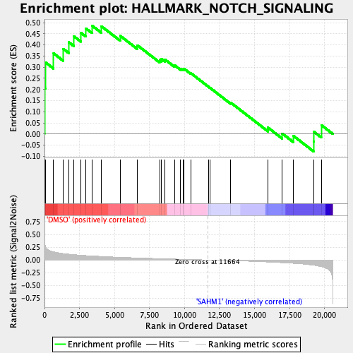

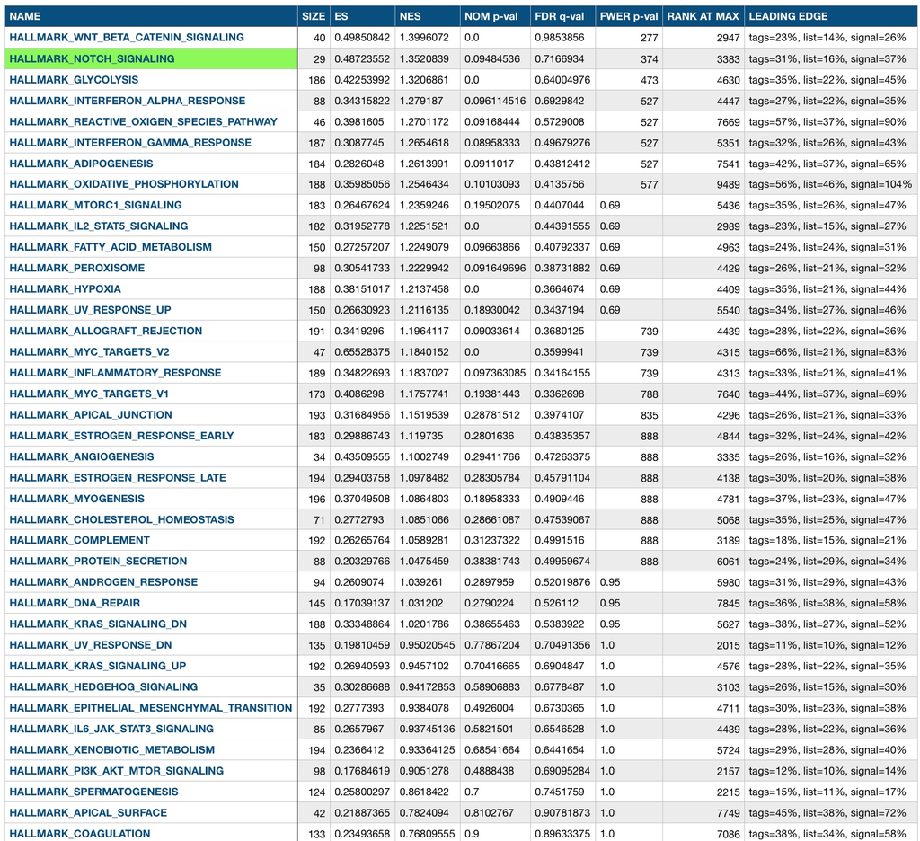

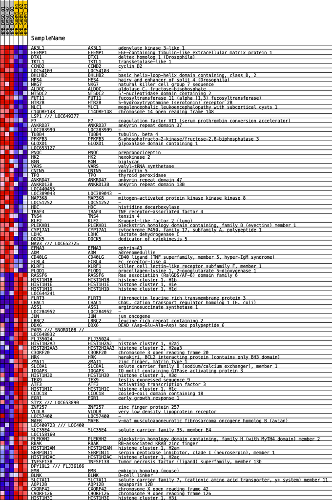

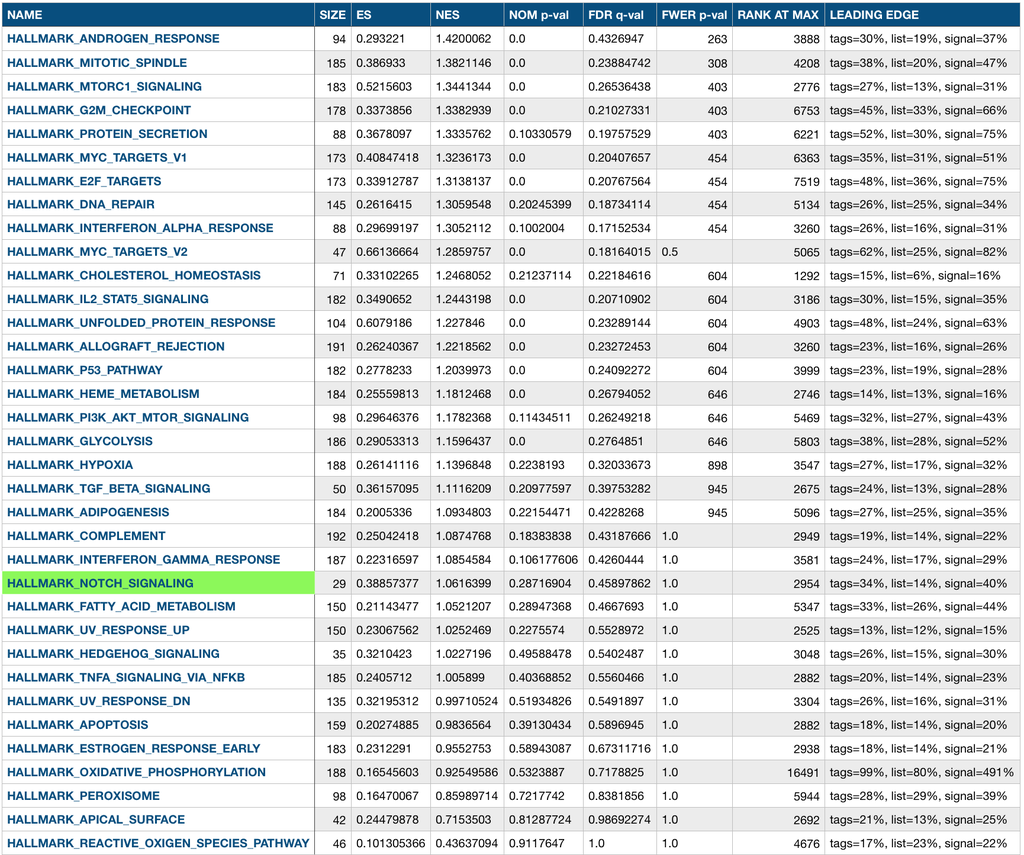

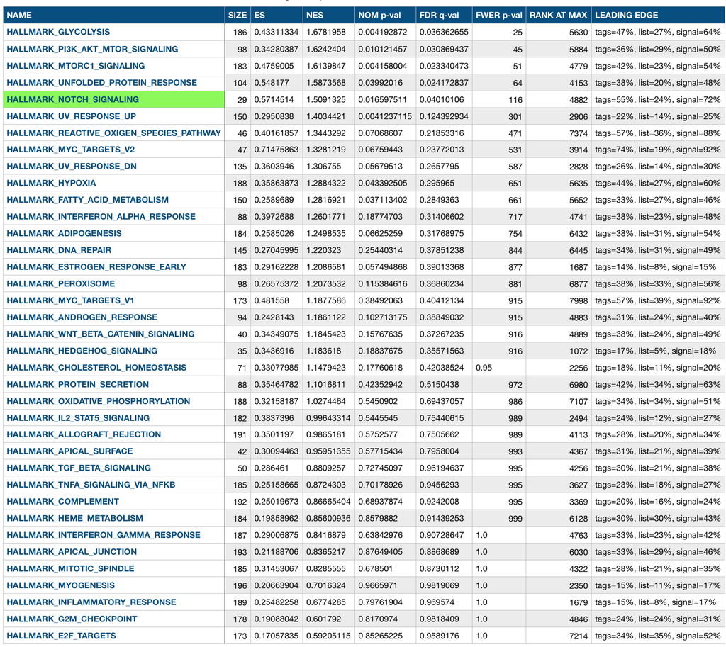

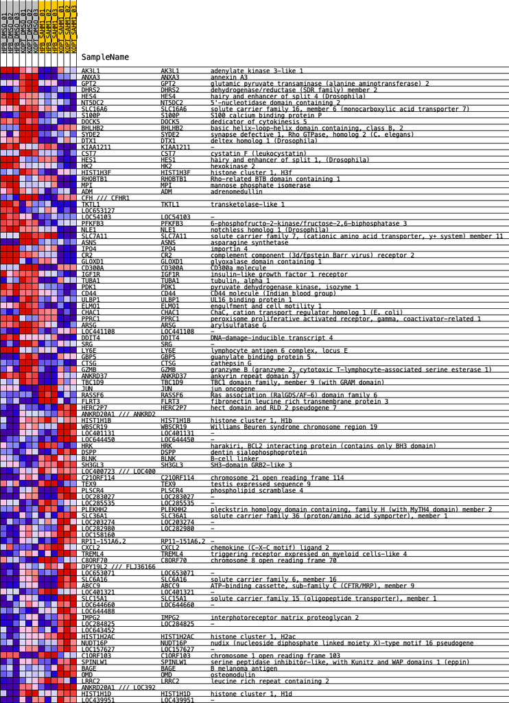

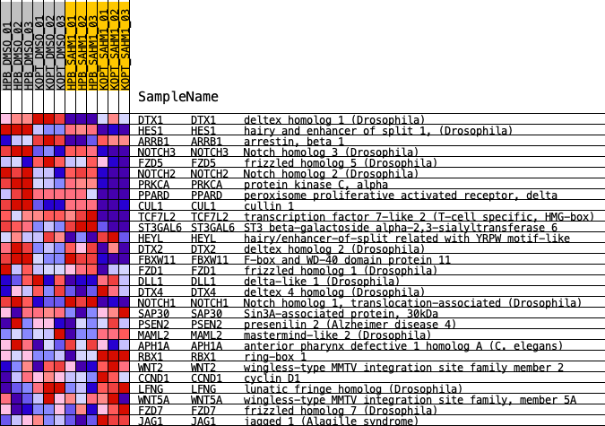

# Outputs

```python
%%bash
jupyter nbconvert --to=latex --template=~/report.tplx TRREP_final.ipynb 1> /dev/null 2> /dev/null
/Library/TeX/texbin/pdflatex -shell-escape TRREP_final 1> /dev/null 2> /dev/null
jupyter nbconvert --to html_embed --template toc2 TRREP_final.ipynb 1> /dev/null 2> /dev/null
```